# Регрессия

### Проблема гетероскадистичности

Давайте воспользуемся небольшим набором данных `diamonds`

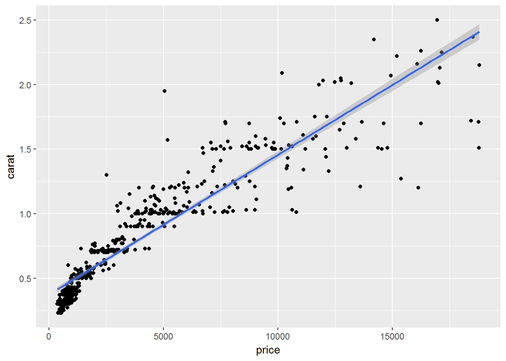

```r
library(ggplot2)
library(dplyr)
diamonds_2 <- sample_n (diamonds,500)
qplot(x=price,y=carat,data=diamonds_2)+
  geom_smooth(method = "lm")
```

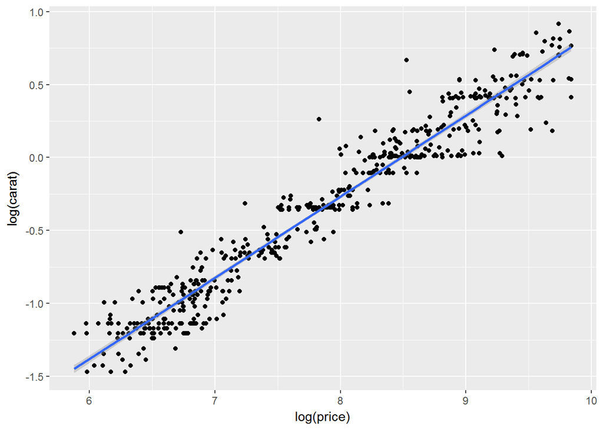

```r
fit_1 <- lm(carat~price,diamonds_2)

qplot(x=log(price),y=log(carat),data=diamonds_2)+
  geom_smooth(method = "lm")
```

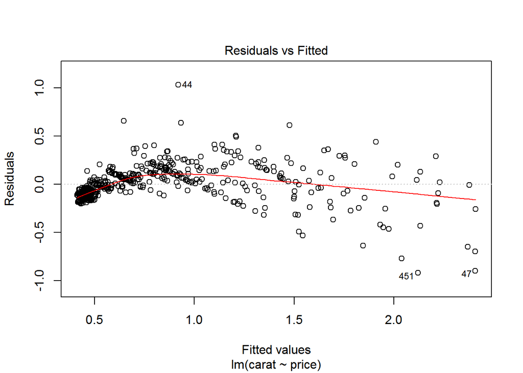

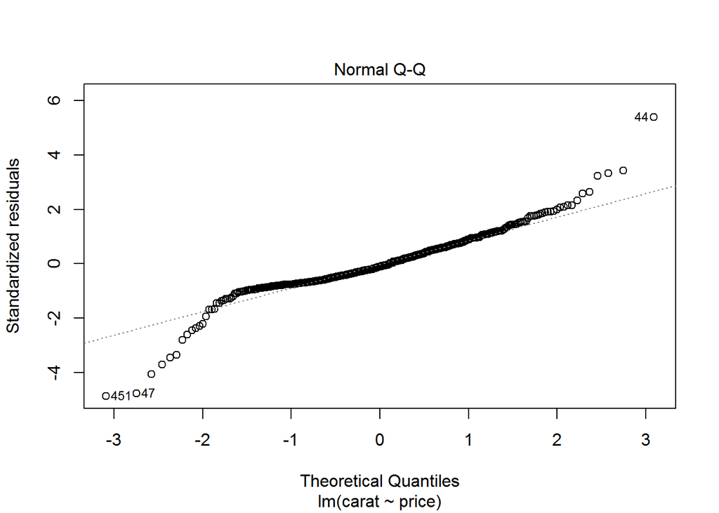

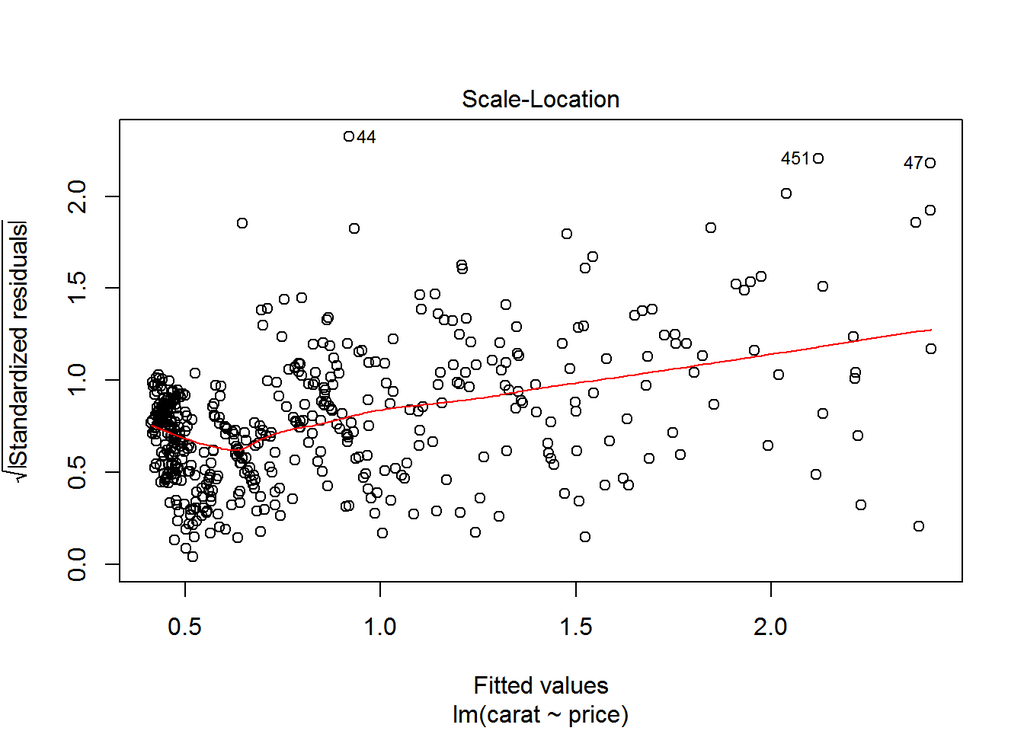

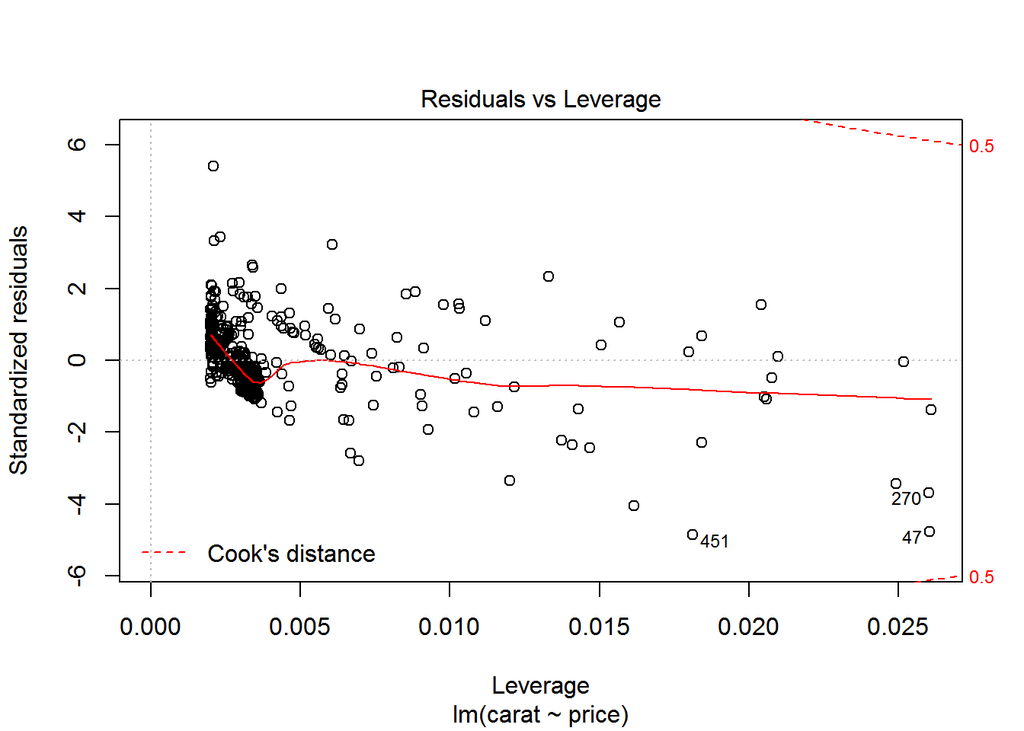

```r
plot(fit_1)
```

Как только вы сделали модель , сразу рисуйте график распределения остатков

**Если мы построим регрессию, где зависимой переменной будет квадрат остатков модели y ~ x, а независимой переменной будет предиктор x, и в этой модели окажется высокий и значимый R квадрат, это означает, что в данных есть гетероскедастичность**

```r
library(lmtest)
bptest(lm(log(price)~log(carat),diamonds_2))
```

```
##
##  studentized Breusch-Pagan test
##
## data:  lm(log(price) ~ log(carat), diamonds_2)
## BP = 5.4992, df = 1, p-value = 0.01903
```

# Мултиколлиенарность

Разберем на примере

```r
library(dplyr)

set.seed(42)
d <- data_frame(y = rnorm(30),
                x_1 = 1:30,
                x_2 = 1:30,
                x_3 = rnorm(30))

fit <- lm(y~.,d)
summary(fit)
```

```
##
## Call:
## lm(formula = y ~ ., data = d)
##
## Residuals:
##     Min      1Q  Median      3Q     Max
## -2.4437 -0.6028  0.0030  0.8309  2.2450
##
## Coefficients: (1 not defined because of singularities)
##             Estimate Std. Error t value Pr(>|t|)
## (Intercept)  0.64427    0.46008   1.400    0.173
## x_1         -0.03894    0.02582  -1.508    0.143
## x_2               NA         NA      NA       NA
## x_3         -0.22905    0.21648  -1.058    0.299
##
## Residual standard error: 1.223 on 27 degrees of freedom
## Multiple R-squared:  0.1161, Adjusted R-squared:  0.05061
## F-statistic: 1.773 on 2 and 27 DF,  p-value: 0.189
```

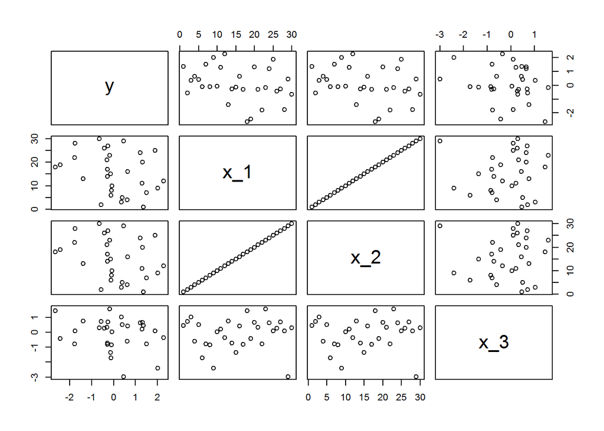

```r
pairs(d)
```

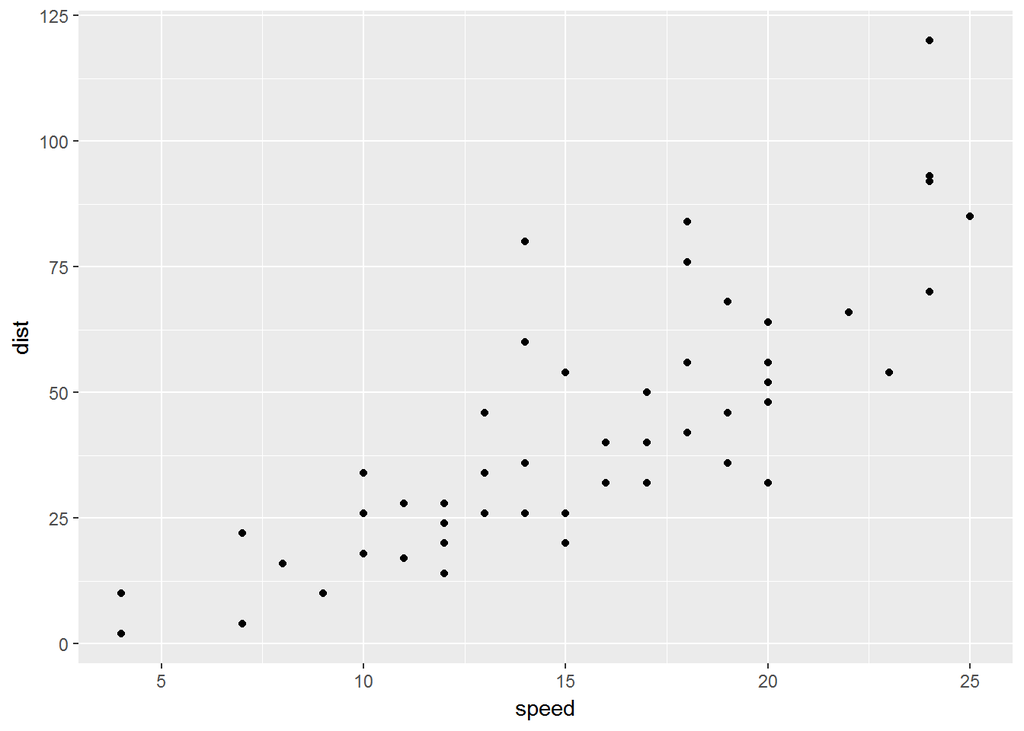

```r
qplot(x=speed,y=dist,data=cars)
```

```r
fit_1 <- lm(dist~speed,cars)
summary(fit_1)
```

```
##
## Call:
## lm(formula = dist ~ speed, data = cars)
##
## Residuals:
##     Min      1Q  Median      3Q     Max
## -29.069  -9.525  -2.272   9.215  43.201
##
## Coefficients:
##             Estimate Std. Error t value Pr(>|t|)
## (Intercept) -17.5791     6.7584  -2.601   0.0123 *
## speed         3.9324     0.4155   9.464 1.49e-12 ***
## ---
## Signif. codes:  0 '***' 0.001 '**' 0.01 '*' 0.05 '.' 0.1 ' ' 1
##
## Residual standard error: 15.38 on 48 degrees of freedom
## Multiple R-squared:  0.6511, Adjusted R-squared:  0.6438
## F-statistic: 89.57 on 1 and 48 DF,  p-value: 1.49e-12
```

```r
cars <- mutate(cars,speed_2 =speed^2,speed_3 = speed^3)
fit_2 <- lm(dist~.,cars)
summary(fit_2)
```

```
##
## Call:
## lm(formula = dist ~ ., data = cars)
##
## Residuals:
##     Min      1Q  Median      3Q     Max
## -26.670  -9.601  -2.231   7.075  44.691
##
## Coefficients:
##              Estimate Std. Error t value Pr(>|t|)
## (Intercept) -19.50505   28.40530  -0.687    0.496
## speed         6.80111    6.80113   1.000    0.323
## speed_2      -0.34966    0.49988  -0.699    0.488
## speed_3       0.01025    0.01130   0.907    0.369
##
## Residual standard error: 15.2 on 46 degrees of freedom
## Multiple R-squared:  0.6732, Adjusted R-squared:  0.6519
## F-statistic: 31.58 on 3 and 46 DF,  p-value: 3.074e-11
```

```r
fit_1 <- lm(Fertility~.,swiss)
summary(fit_1)
```

```
##
## Call:
## lm(formula = Fertility ~ ., data = swiss)
##
## Residuals:
##      Min       1Q   Median       3Q      Max
## -15.2743  -5.2617   0.5032   4.1198  15.3213
##
## Coefficients:
##                  Estimate Std. Error t value Pr(>|t|)
## (Intercept)      66.91518   10.70604   6.250 1.91e-07 ***
## Agriculture      -0.17211    0.07030  -2.448  0.01873 *
## Examination      -0.25801    0.25388  -1.016  0.31546
## Education        -0.87094    0.18303  -4.758 2.43e-05 ***
## Catholic          0.10412    0.03526   2.953  0.00519 **
## Infant.Mortality  1.07705    0.38172   2.822  0.00734 **
## ---
## Signif. codes:  0 '***' 0.001 '**' 0.01 '*' 0.05 '.' 0.1 ' ' 1
##
## Residual standard error: 7.165 on 41 degrees of freedom
## Multiple R-squared:  0.7067, Adjusted R-squared:  0.671
## F-statistic: 19.76 on 5 and 41 DF,  p-value: 5.594e-10
```

```r
# мултиколлинеарность есть или нет?

cor.test(~ Fertility + Examination,swiss)
```

```
##
##  Pearson's product-moment correlation
##
## data:  Fertility and Examination
## t = -5.6753, df = 45, p-value = 9.45e-07
## alternative hypothesis: true correlation is not equal to 0
## 95 percent confidence interval:
##  -0.7870674 -0.4403995
## sample estimates:
##        cor
## -0.6458827
```

```r
library(car)
library(dplyr)
vif(fit_1)
```

```
##      Agriculture      Examination        Education         Catholic
##         2.284129         3.675420         2.774943         1.937160
## Infant.Mortality
##         1.107542
```

```r
fit_2 <- lm(Fertility~.,select(swiss, -Examination))
summary(fit_2)
```

```
##
## Call:
## lm(formula = Fertility ~ ., data = select(swiss, -Examination))
##
## Residuals:
##      Min       1Q   Median       3Q      Max
## -14.6765  -6.0522   0.7514   3.1664  16.1422
##
## Coefficients:
##                  Estimate Std. Error t value Pr(>|t|)
## (Intercept)      62.10131    9.60489   6.466 8.49e-08 ***
## Agriculture      -0.15462    0.06819  -2.267  0.02857 *
## Education        -0.98026    0.14814  -6.617 5.14e-08 ***
## Catholic          0.12467    0.02889   4.315 9.50e-05 ***
## Infant.Mortality  1.07844    0.38187   2.824  0.00722 **
## ---
## Signif. codes:  0 '***' 0.001 '**' 0.01 '*' 0.05 '.' 0.1 ' ' 1
##
## Residual standard error: 7.168 on 42 degrees of freedom
## Multiple R-squared:  0.6993, Adjusted R-squared:  0.6707
## F-statistic: 24.42 on 4 and 42 DF,  p-value: 1.717e-10
```

```r
vif(fit_2)
```

```
##      Agriculture        Education         Catholic Infant.Mortality
##         2.147153         1.816361         1.299916         1.107528
```

Попробуем посмотреть для каждого предиктора то, насколько хорошо он обьясняется другими предикторами. Vif - показывает, насколько хорошо выбранный предиктор обьясняется другими предикторами.

Квадратный корень VIF показывает, во сколько раз больше стала стандартная ошибка данного коэффицента, по сравнению с ситуацией, если бы данный предиктор был бы абсолюнто независимым от других предикторов. **Пример** Если при некотором предикторе VIF равен 5,27 (2,3) это означает, что стандартная ошибка этого коэффициента в 2,3 раза больше, по сравнению с ситуацией, когда этот предиктор был бы нескореллирован с другими

Давайте реализуем простейший вариант теста для проверки наличия гетероскедастичности. Напишите функцию hetero_test, которая получает на вход набор данных. Первая колонка в данных - зависимая переменная, остальные колонки - независимые. Функция строит регрессионную модель, используя эти переменные, а затем проверяет, есть ли в данных гетероскедастичность.

Для этого функция строит вспомогательную регрессию, в которой зависимая переменная - это квадраты остатков исходной модели, а независимые переменные - это предикторы из исходной модели. Функция должна возвращать значение R квадрат этой вспомогательной модели.

```r
hetero_test <-  function(x){
  dep <- x[,1]
  x[,1] <- NULL
  fit1 <- lm(dep~.,x)

  fit2 <- lm(fit1$residuals*fit1$residuals~.,x)
  summary(fit2)$adj.r.squared
    }
```

# Нарушение допущения о независимости наблюдений

Первым источником зависимости наших проектах, являются зависимые измерения повторные измерения * **Повторные измерения** на одних и тех же людей делаем разные опыты * **Повторные пробы** в течении года на одном человеке делать опыт * **Кластеризация данны** опыт на нескольких больницах

## Проблемы, которые могут породить эти зависимости

- Повторные измерение
- Снижение чувствительности теста
- Искусственное увеличение мощности теста(псевдорепликация) - 100 опытов на 5 людях по 20 раз
- Несбалансированный дизайн
- Искажение результатов
- Кластеризация данных
- Искажение результатов

# Смешанные регрессионные модели, реализация

**Эффект -** влияние нп с помощью которой мы предсказываем зп

**Фиксированный жффект -** влияние нп переменной, представляющее основной интерес для исследования (обычно варьируется человеков)

**Случайный эффект -** влияние нп, не представляющее первостепенного интереса для исследователя.

# `lmer(DV ~ IV + (1 + IV | RV), data = my_data)`

```r
library(mlmRev)
library(lme4)

data("Exam")
str(Exam)
```

```
## 'data.frame':    4059 obs. of  10 variables:
##  $ school  : Factor w/ 65 levels "1","2","3","4",..: 1 1 1 1 1 1 1 1 1 1 ...
##  $ normexam: num  0.261 0.134 -1.724 0.968 0.544 ...
##  $ schgend : Factor w/ 3 levels "mixed","boys",..: 1 1 1 1 1 1 1 1 1 1 ...
##  $ schavg  : num  0.166 0.166 0.166 0.166 0.166 ...
##  $ vr      : Factor w/ 3 levels "bottom 25%","mid 50%",..: 2 2 2 2 2 2 2 2 2 2 ...
##  $ intake  : Factor w/ 3 levels "bottom 25%","mid 50%",..: 1 2 3 2 2 1 3 2 2 3 ...
##  $ standLRT: num  0.619 0.206 -1.365 0.206 0.371 ...
##  $ sex     : Factor w/ 2 levels "F","M": 1 1 2 1 1 2 2 2 1 2 ...
##  $ type    : Factor w/ 2 levels "Mxd","Sngl": 1 1 1 1 1 1 1 1 1 1 ...
##  $ student : Factor w/ 650 levels "1","2","3","4",..: 143 145 142 141 138 155 158 115 117 113 ...
```

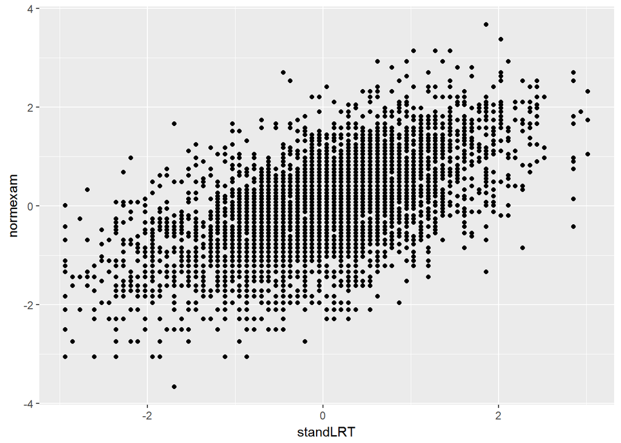

```r
library(ggplot2)

 ggplot(data = Exam, aes(x = standLRT, y = normexam)) +
  geom_point()
```

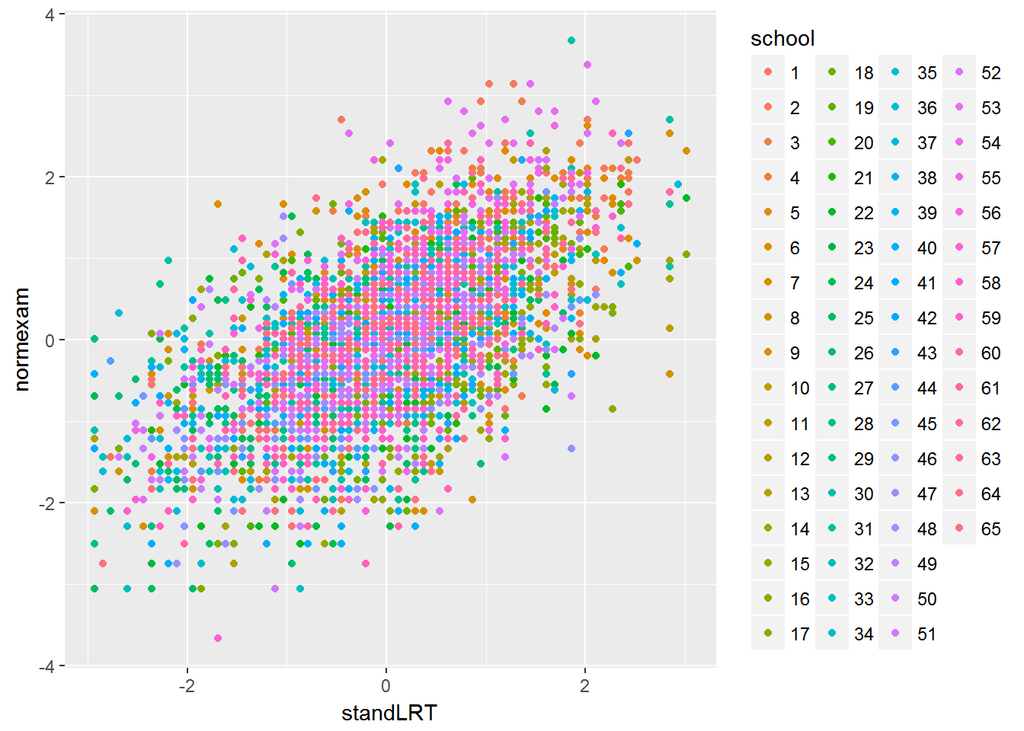

```r
 ggplot(data = Exam, aes(x = standLRT, y = normexam, col = school)) +
  geom_point()
```

```r
 # для начала с одним главным эффектом модель

 Model1 <- lm(normexam ~ standLRT, data=Exam)
 summary(Model1)
```

```
##
## Call:
## lm(formula = normexam ~ standLRT, data = Exam)
##
## Residuals:
##      Min       1Q   Median       3Q      Max
## -2.65615 -0.51848  0.01265  0.54399  2.97399
##
## Coefficients:
##              Estimate Std. Error t value Pr(>|t|)
## (Intercept) -0.001191   0.012642  -0.094    0.925
## standLRT     0.595057   0.012730  46.744   <2e-16 ***
## ---
## Signif. codes:  0 '***' 0.001 '**' 0.01 '*' 0.05 '.' 0.1 ' ' 1
##
## Residual standard error: 0.8054 on 4057 degrees of freedom
## Multiple R-squared:   0.35,  Adjusted R-squared:  0.3499
## F-statistic:  2185 on 1 and 4057 DF,  p-value: < 2.2e-16
```

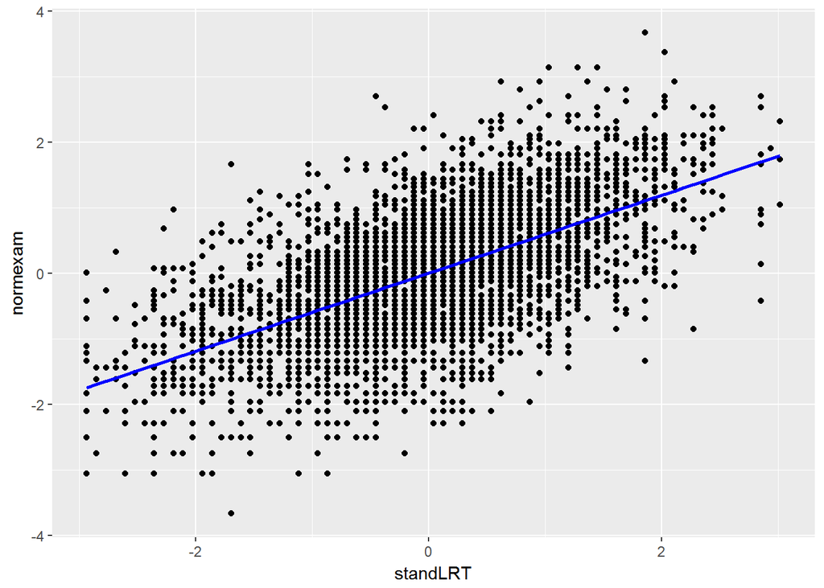

```r
 Exam$Model1_pred <- predict(Model1)


 ggplot(data = Exam, aes(x = standLRT, y = normexam)) +
  geom_point() +
  geom_line(data = Exam, aes(x = standLRT, y = Model1_pred), col = 'blue', size = 1)
```

```r
 # Модель со случайным эффектом
 Model2 <- lmer(normexam ~ standLRT + (1|school), data=Exam)
summary(Model2)
```

```
## Linear mixed model fit by REML ['lmerMod']
## Formula: normexam ~ standLRT + (1 | school)
##    Data: Exam
##
## REML criterion at convergence: 9368.8
##
## Scaled residuals:
##     Min      1Q  Median      3Q     Max
## -3.7166 -0.6302  0.0294  0.6849  3.2673
##
## Random effects:
##  Groups   Name        Variance Std.Dev.
##  school   (Intercept) 0.09384  0.3063
##  Residual             0.56587  0.7522
## Number of obs: 4059, groups:  school, 65
##
## Fixed effects:
##             Estimate Std. Error t value
## (Intercept) 0.002323   0.040354    0.06
## standLRT    0.563307   0.012468   45.18
##
## Correlation of Fixed Effects:
##          (Intr)
## standLRT 0.008
```

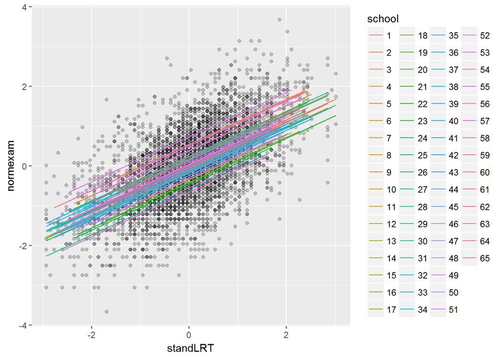

```r
Exam$Model2_pred <- predict(Model2)
ggplot(data = Exam, aes(x = standLRT, y = normexam)) +
  geom_point(alpha = 0.2) +
  geom_line(data = Exam, aes(x = standLRT, y = Model2_pred, col = school))
```

## В том примере мы увидели каким образом мы можем учесть тот факт, что в принципе уровень сдачи выпускного экхамена в разных школах в среднем различаться, а сейчас мы попробуем посмотреть каким образом можно учесть тот факт что взаимосвязсь между вступительным и выпускным в разных школах так же может различаться

```r
Model3 <- lmer(normexam ~ standLRT + (1 + standLRT|school), data=Exam)
summary(Model3)
```

```
## Linear mixed model fit by REML ['lmerMod']
## Formula: normexam ~ standLRT + (1 + standLRT | school)
##    Data: Exam
##
## REML criterion at convergence: 9327.6
##
## Scaled residuals:
##     Min      1Q  Median      3Q     Max
## -3.8323 -0.6317  0.0339  0.6834  3.4562
##
## Random effects:
##  Groups   Name        Variance Std.Dev. Corr
##  school   (Intercept) 0.09212  0.3035
##           standLRT    0.01497  0.1223   0.49
##  Residual             0.55364  0.7441
## Number of obs: 4059, groups:  school, 65
##
## Fixed effects:
##             Estimate Std. Error t value
## (Intercept) -0.01165    0.04011   -0.29
## standLRT     0.55653    0.02011   27.67
##
## Correlation of Fixed Effects:
##          (Intr)
## standLRT 0.365
```

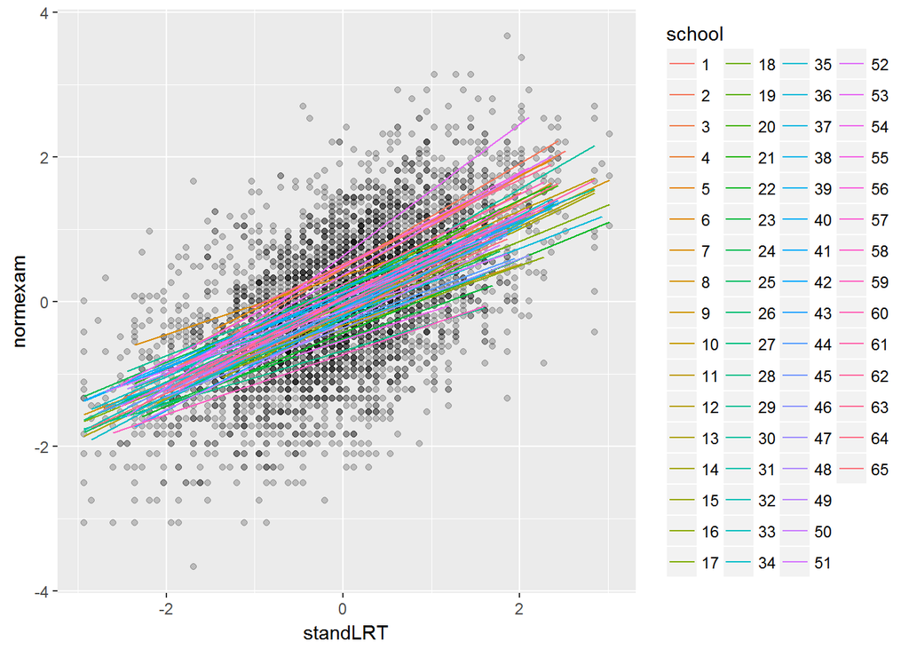

```r
Exam$Model3_pred <- predict(Model3)
ggplot(data = Exam, aes(x = standLRT, y = normexam)) +
  geom_point(alpha = 0.2) +
  geom_line(data = Exam, aes(x = standLRT, y = Model3_pred, col = school))
```

```r
Model4 <- lmer(normexam ~ standLRT + (0 + standLRT|school), data=Exam)
summary(Model4)
```

```
## Linear mixed model fit by REML ['lmerMod']
## Formula: normexam ~ standLRT + (0 + standLRT | school)
##    Data: Exam
##
## REML criterion at convergence: 9700.6
##
## Scaled residuals:
##     Min      1Q  Median      3Q     Max
## -3.2793 -0.6501  0.0241  0.6833  3.9119
##
## Random effects:
##  Groups   Name     Variance Std.Dev.
##  school   standLRT 0.0259   0.1609
##  Residual          0.6251   0.7906
## Number of obs: 4059, groups:  school, 65
##
## Fixed effects:
##             Estimate Std. Error t value
## (Intercept) -0.01463    0.01284  -1.139
## standLRT     0.58782    0.02423  24.256
##
## Correlation of Fixed Effects:
##          (Intr)
## standLRT 0.000
```

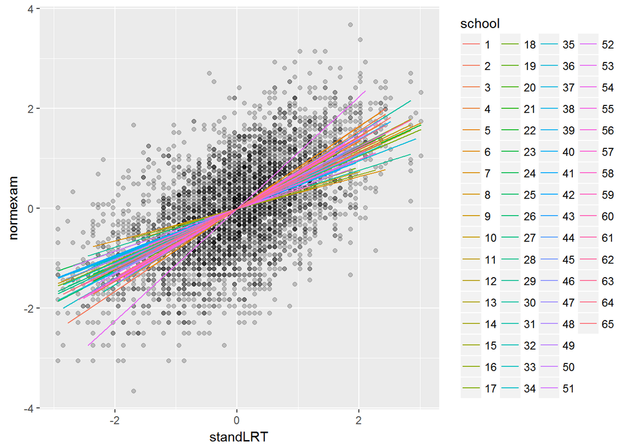

```r
Exam$Model4_pred <- predict(Model4)
ggplot(data = Exam, aes(x = standLRT, y = normexam)) +
  geom_point(alpha = 0.2) +
  geom_line(data = Exam, aes(x = standLRT, y = Model4_pred, col = school))
```

таким образом свободный член не отличается

### а если нескоореллированные случайные эффекты, то (случайный эффект и угловой коэффицент)

```r
Model5 <- lmer(normexam ~ standLRT + (1|school) + (0 + standLRT|school), data=Exam)
summary(Model5)
```

```
## Linear mixed model fit by REML ['lmerMod']
## Formula: normexam ~ standLRT + (1 | school) + (0 + standLRT | school)
##    Data: Exam
##
## REML criterion at convergence: 9335.7
##
## Scaled residuals:
##     Min      1Q  Median      3Q     Max
## -3.8108 -0.6347  0.0273  0.6846  3.4465
##
## Random effects:
##  Groups   Name        Variance Std.Dev.
##  school   (Intercept) 0.09195  0.3032
##  school.1 standLRT    0.01474  0.1214
##  Residual             0.55363  0.7441
## Number of obs: 4059, groups:  school, 65
##
## Fixed effects:
##              Estimate Std. Error t value
## (Intercept) -0.008091   0.040084  -0.202
## standLRT     0.557023   0.020097  27.717
##
## Correlation of Fixed Effects:
##          (Intr)
## standLRT 0.005
```

# Статистическая значимость, обобщённые модели и случайные эффекты